At the end of January, in a series of blog posts on [Sharp Football Analytics](http://www.sharpfootballanalysis.com/blog/), an analysis was presented that showed that the New England Patriots suddenly improved in their ability to not fumble the football after 2006. What’s more, the author contended that their new and improved lack of fumbles was beyond the realm of pure chance.

Due to some valid criticism of some of the methodology, many analysts and commentators threw out the analysis as junk. Rather than list each separately, here is a [link](http://fivethirtyeight.com/datalab/your-guide-to-deflate-gateballghazi-related-statistical-analyses/) to 538’s roundup.

I was left unsatisfied by these responses because so many were overly snarky. Also, in his own response, Sharp contended that neither of his two main points had been rebutted, which I agreed with. So I did the analysis for myself. I set out to investigate the author’s two main points (I’m paraphrasing):

1. From 2000-2006 the New England Patriots were league average when it come to the frequency in which they fumble. Starting in 2007 and then onward, they improved sharply and drastically.
2. Their degree of improvement was so great that it is unlikely they would have improved this drastically by chance alone.

# Data

## Source and Preparation

I used data that I purchased from [Armchairanalysis.com](http://www.armchairanalysis.com/). I bought the research license which only includes data though the 2013 season as of this writing, so no data from this most recent season is included. Any trends that were visible from 2007-2014 should also be visible from 2007-2013.

One mistake I discovered in Sharp’s analysis was that he attributed the drastic reduction of fumbles to a rule change that allowed visiting teams to supply their own footballs starting with the 2007 season. After more Googling than I thought would be necessary, I found that this rule change went into effect prior to the 2006 season (source). Still, I will investigate Sharp’s claims as is. Pre-2007 vs. 2007 and onward.

As other’s responses have pointed out, due to the “K” balls, the most appropriate data points to analyze would be those plays in which the QB-selected balls were in use. To avoid inflating the available pool of “fumble eligible plays”, only plays that were rushing attempts, completed passes or sacks will be analyzed. Additionally, only regular season data will be used. All code used to wrangle the data, perform the analysis and create graphics and be found in a github [repository](https://github.com/johnckane/my_data_sandbox/tree/master/Fumbles).

## Metric

Here’s a brief look at the data. “off” stands for offense and “fep” is “fumble eligible plays”.

```
##   season off fumbles fep fumble_rate_100
## 1   2000 ARI      24 697        3.443329
## 2   2000 ATL      22 700        3.142857
## 3   2000 BAL      22 842        2.612827
## 4   2000 BUF      23 849        2.709069
## 5   2000 CAR      18 773        2.328590
## 6   2000 CHI      21 757        2.774108
```

# Did the Patriots fumbling rates drastically improve in 2007?

The short answer to this question is yes, they did. Looking at their cumulative fumble rate from 2000-2006 and then from 2007-2013 we see this:

```
## Source: local data frame [2 x 4]
##
##   post07 total_plays total_fumbles fumble_rate_100
## 1      0        5798           140        2.414626
## 2      1        6195            84        1.355932
```

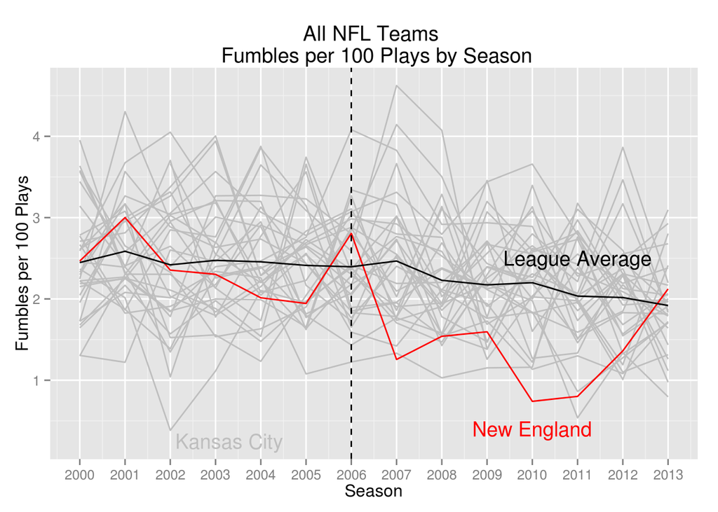

# Was their new performance too statistically unlikely to be a coincidence?

There are multiple angles to take to investigate this question. First, let’s consider just how well New England has done in terms of fumbles per 100 plays relative to other teams in the league.

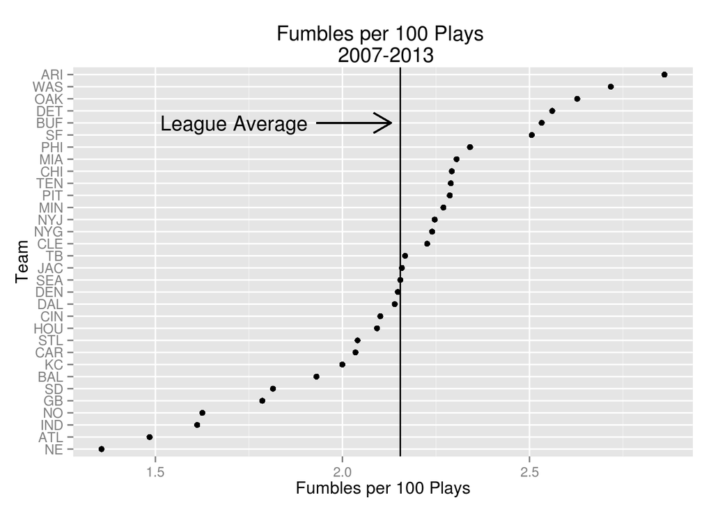

New England has lead the league in this category, and there’s considerable distance between them and Atlanta. On the other end of the spectrum sits Arizona. If we assume the distribution is normal (the QQ-plot, not displayed, indicated that is a reasonable assumption) this is how likely we are to see these values:

```
##   team      pre     post    post_z
## 1  ARI 3.074916 2.860883  2.061144
## 2  ATL 2.530253 1.484550 -1.955835
## 3   NE 2.414626 1.355932 -2.331221
```

```r
## NE
1/pnorm(-2.331221,0,1)
```

```
## [1] 101.3083
```

```r
## ATL
1/pnorm(-1.955835,0,1)
```

```
## [1] 39.61605
```

```r
## ARI
1/(1-pnorm(2.061144))
```

```
## [1] 50.90444
```

So here we see that New England’s outlier status has been estimated by Sharp as 1 in over 16,000, by the Regressing Deadspin article as 1 in 297, and now here as 1 in 101. That’s still remarkable and the next closest team, in terms of unlikeliness (Arizona) clocks in at 1 in 51, albeit in the opposite direction.

But the question is, should we attribute New England being more than 2 times more unlikely then the next closest outlier to nefarious behavior on their part? I don’t think so. Despite the assumptions we made to do inference on the data points, I don’t think that these data points are random. If you look at the top and bottom teams in the above plot, we have the top five as NE, ATL, IND, NO, GB; while the bottom five are ARI, WAS, OAK, DET, BUF. A confounding factor with these rankings is the success of each franchise from 2007-2013. Before this, wouldn’t you have expected New England to be one of the best in the league at not turning the ball over considering all their success? Wouldn’t they have been near the top? It may be more surprising that they were league average during the period that they won the first three Super Bowls of the Belichick-Brady era, while winning zero from 2007-2013 when they dominated this statistic.

A reasonable counterpoint to that argument could be the degree by which they improved. They were league average for seven seasons, then the best team in the league over the next seven. To analyze this point I’ll look at how much they improved on a fumble per 100 play basis.

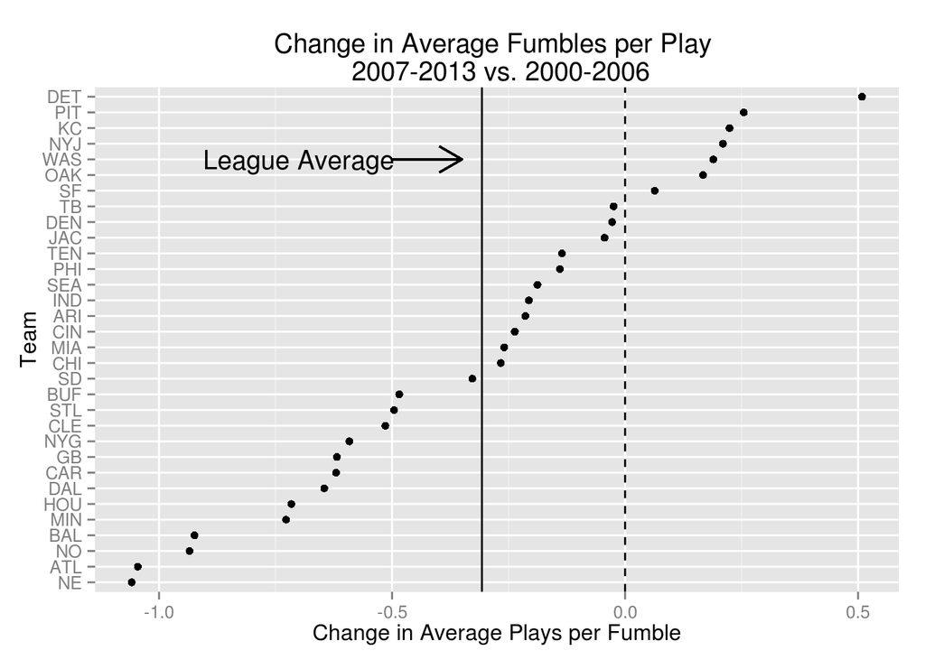

New England improved by nearly 1.06 fumbles per 100 plays, tops in the league. But Atlanta was right behind them at 1.05. More interesting than that is that all but seven teams improved in this category. Lowly Detroit is actually further away from the league average, albeit going in the other direction. New England isn’t an outlier, just an extreme observation.

Now I’ll look at New England’s yearly ranking in the category. This will mitigate the influence any outlier season has on the cumulative rates.

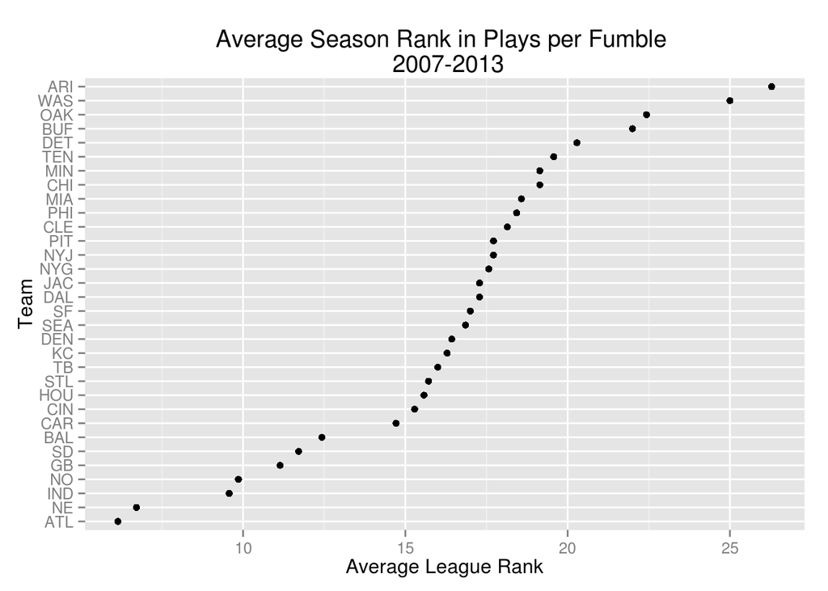

New England is near the top, but Atlanta, on average, has ranked higher than New England when it comes to fumbles.

Again, we could take the angle of improvement during the time period. Here’s how each franchise’s average ranking either improved or regressed from 2000-2006 to 2007-2013.

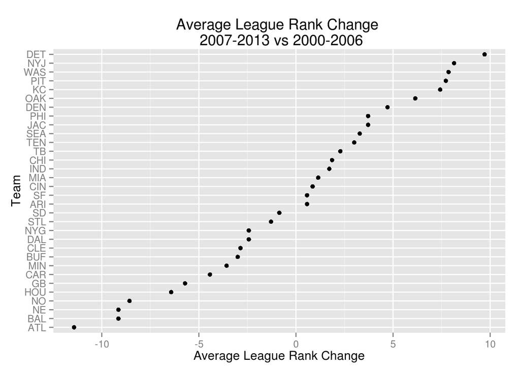

Here New England is tied for second in the NFL with Baltimore, moving up on average 9.1 spots while Atlanta moved up 11.4 spots. Again we see New England is not an outlier, just an extreme observation.

# On dome teams, playing surfaces and weather-effects

In an effort to mitigate any advantages teams who play less frequenly in wet weather have in fumbling less, other analyses restricted plays analyzed to either eliminate dome teams, or only games being played outside. The real issue is not whether or not the game is played outside, but whether the weather conditions would make the ball slick. Luckily, the Armchair Analytics data provides weather conditions for each game.

When looking at how often games are played in these conditions I found that New England played only 13 of 112 regular season games in wet conditions from 2007-2013. New England is one of the teams most prone to playing in fumble-favorable weather, but do so so rarely in comparison to good conditions (inside or out) that restricing analysis to games played in these conditions necessarily lowers the sample size and is unlikely to affect the big picture when it comes to fumble rates. Nevertheless, I conducted the analysis and will present it below.

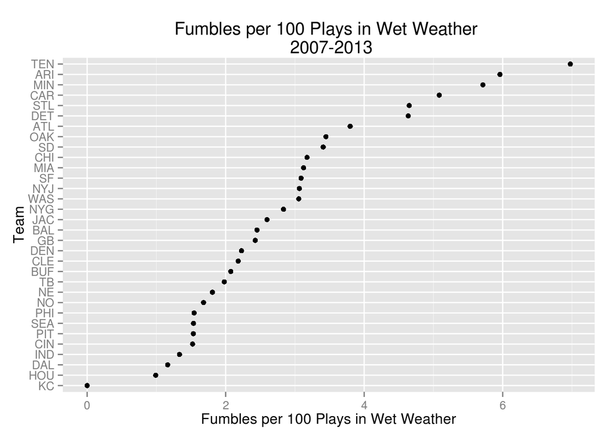

So in wet weather New England (774 fumble eligible plays) ranks 10th behind outdoor teams like Philadelphia (259), Seattle (521), Pittsburgh (652), and Cincinnati(394) and Kansas City (100). Note Kansas City has never fumbled in wet conditions from 2007-2013! Granted they only had 100 fumble eligible plays, but it doesn’t look like New England outperforms teams in those conditions. Again, because so few games are actually played in these conditions, the sample sizes wouldn’t be large enough to influence the overall story here.

# How do players’ fumble rates change when playing for Patriots vs. Other Teams?

A final analysis I conducted was how New England players fumbled when they played with Patriots vs. other teams I identified 12 players by examining the Patriots roster on [pro-football-reference.com](http://www.pro-football-reference.com/teams/nwe/) who got considerable touches playing for both the Patriots and other teams from 2007-2013. I was then able to compare the fumble rates for both teams. These are displayed below in a bar chart. I annotated each bar with the number of touches each bar represents.

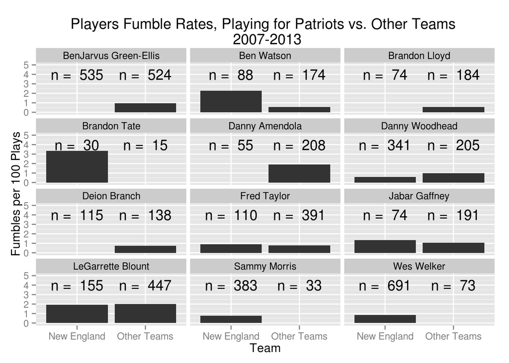

Looking at these plots with the annotations I think it’s only fair to compare several of the 12 players represented. Through a combination of either too few plays in general(e.g. Brandon Tate) and too large of an inbalance between plays for New England vs. plays for other teams (e.g. Wes Welker) I think it’s only safe to compare the following players:

- BenJarvus Green Ellis: never fumbled with New England, has fumbled five times with other teams.
- Ben Watson: fumbled at a higher rate with New England
- Brandom Lloyd: fumbled at a lower rate with New England
- Danny Woodhead: fumbled at a lower rate with New England
- Deion Branch: fumbled at a lower rate with New England
- Fred Taylor: fumbled at a higher rate with New England
- Jabar Gafney: fumbled at a higher rate with New England
- LeGarrette Blount: fumbled at a lower rate with New England

So 5 of 8 analyzed players have fumbled with lower rates with New England. That shouldn’t raise any eyebrows. One caveat here is that fumbles are rare events, so large samples are needed. Two players pass the eye test when it comes to a considerable sample size both with New England and then other teams: Green-Ellis and Woodhead. Both had lower fumble rates with New England.

# Conclusion

Sharp’s two main points were (again I’m paraphrasing):

1. New England suddenly and drastically improved their fumble rates following the 2006 season.
2. Their improvement was so great that it is unlikely to have occurred by chance alone.

I think I’ve made a case that

1. Yes, New England did improve suddenly and drastically in 2007 compared to where they had been from 2000-2006.
2. While New England is an outlier for that time period, fumble rates aren’t technically random. We see the successful franchises of the recent past at the top of that list while the unsuccessful ones at the bottom. When you consider raw improvement and league rankings, New England is an extreme observation but not an outlier.
3. While playing for New England some players fumbled far far less then when playing for other teams (BenJarvus Green-Ellis) but in general it’s a toss-up as to which team they fumbled at a higher rate with.